# Individual Assignment 2 : Classification & Logistic Regression

(Total of 20 marks)

Instructions:

- You may work on this file directly, and fill in your answers/code below. Add more cells if necessary.
- For code cells, run your code and make sure the output is visible.
- Save the notebook as a HTML file (File > Download as > HTML) and **rename it with your student ID** (e.g. e01234567.html)
- Submit this to Canvas under Assignment 2

This assignment will require the following dataset:

- `penguins.csv`

This dataset contains information about 3 species of penguins (Adelie, Gentoo, Chinstrap), recorded by the Palmer Station in Antarctica.

We will train a logistic regression model to identify chinstrap penguins.

```python
import numpy as np
import pandas as pd

from matplotlib import pyplot as plt
import seaborn as sns

df = pd.read_csv('penguins.csv', index_col = 0)
df
```

|  | species_short | island | culmen_length_mm | culmen_depth_mm | flipper_length_mm | body_mass_g | sex |
| --- | --- | --- | --- | --- | --- | --- | --- |
| 0 | Adelie | Torgersen | 39.1 | 18.7 | 181 | 3750 | MALE |
| 1 | Adelie | Torgersen | 39.5 | 17.4 | 186 | 3800 | FEMALE |
| 2 | Adelie | Torgersen | 40.3 | 18.0 | 195 | 3250 | FEMALE |
| 3 | Adelie | Torgersen | 36.7 | 19.3 | 193 | 3450 | FEMALE |
| 4 | Adelie | Torgersen | 39.3 | 20.6 | 190 | 3650 | MALE |
| ... | ... | ... | ... | ... | ... | ... | ... |
| 328 | Gentoo | Biscoe | 47.2 | 13.7 | 214 | 4925 | FEMALE |
| 329 | Gentoo | Biscoe | 46.8 | 14.3 | 215 | 4850 | FEMALE |
| 330 | Gentoo | Biscoe | 50.4 | 15.7 | 222 | 5750 | MALE |
| 331 | Gentoo | Biscoe | 45.2 | 14.8 | 212 | 5200 | FEMALE |
| 332 | Gentoo | Biscoe | 49.9 | 16.1 | 213 | 5400 | MALE |

333 rows × 7 columns

### 1. Compute (and display) the number of each species in the dataset. Is this a balanced or imbalanced dataset?

(1 mark)

```python
Gentoo = df[df['species_short'] == 'Gentoo'].shape[0]
Adelie = df[df['species_short'] == 'Adelie'].shape[0]
Chinstrap = df[df['species_short'] == 'Chinstrap'].shape[0]

num_species = {
    'Gentoo' : Gentoo,
    'Adelie' : Adelie,
    'Chinstrap' : Chinstrap
}

num_species
```

```
{'Gentoo': 119, 'Adelie': 146, 'Chinstrap': 68}
```

```python
df['species_short'].value_counts()
```

```
Adelie       146
Gentoo       119
Chinstrap     68
Name: species_short, dtype: int64
```

Answer: Since we are only interested in Chinstrap penguins, we have an imbalanced dataset with 68 rows of class Chinstrap and 265 rows belonging to the other two species of penguins

### 2. Use seaborn's `pairplot` to visualize the distribution of features across species. Based on the plot, answer questions 2(a), 2(b) and 2(c) below.

(4 marks)

Note: pairplot will only display numerical features; that's ok.

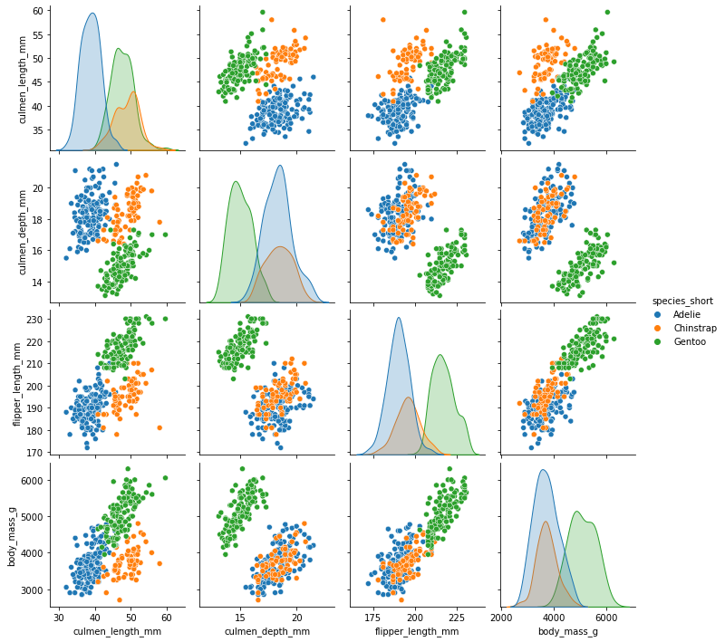

```python
sns.pairplot(df, hue = 'species_short')
```

#### 2(a). Is there a *single* feature that distinguishes *gentoo* penguins from the rest? If so, what feature would you use? If not, explain why not.

Answer:

#### 2(b). Is there a *single* feature that distinguishes *chinstrap* penguins from the rest? If so, what feature would you use? If not, explain why not.

Answer:

#### 2(c). Which 2 features would you use to distinguish chinstrap penguins from the rest?

Answer: `culmen_length_mm` and `body_mass_g` are two features which display the best separation of chinstrap penguins from the rest. While `culmen_length_mm` and `flipper_length_mm` also displays a considerable level of separation, the former pair appears to form a sharper boundary between chisntrap penguins and the other penguins.

We will train logistic regression models on this data, and evaluate the performance.

Throughout, we will set the target `y` to be `True` for chinstrap and `False` for others.

```python
y = df['species_short'] == 'Chinstrap'
y
```

```
0      False
1      False
2      False
3      False
4      False
       ...
328    False
329    False
330    False
331    False
332    False
Name: species_short, Length: 333, dtype: bool
```

### 3. Create (and display) a DataFrame `X` with just the 2 features that you selected in 2(c).

(1 mark)

```python
X = df[['culmen_length_mm', 'body_mass_g']]
X
```

|  | culmen_length_mm | body_mass_g |
| --- | --- | --- |
| 0 | 39.1 | 3750 |
| 1 | 39.5 | 3800 |
| 2 | 40.3 | 3250 |
| 3 | 36.7 | 3450 |
| 4 | 39.3 | 3650 |
| ... | ... | ... |
| 328 | 47.2 | 4925 |
| 329 | 46.8 | 4850 |
| 330 | 50.4 | 5750 |
| 331 | 45.2 | 5200 |
| 332 | 49.9 | 5400 |

333 rows × 2 columns

### 4. Make a pipeline consisting of a Standard Scaler followed by Logistic Regression.

(1 mark)

For logistic regression, set the `penalty` parameter to `'none'` (this will give "ordinary" logistic regression, i.e. the un-regularized version).

```python
from sklearn.pipeline import make_pipeline
from sklearn.preprocessing import StandardScaler
from sklearn.linear_model import LogisticRegression

model = make_pipeline(StandardScaler(), LogisticRegression(penalty = 'none'))
```

### 5. Make a cross-validator to do stratified 5-fold cross-validation.

(1 mark)

Make sure to set `shuffle` to `True`. You may use `2022` as your random state.

```python
from sklearn.model_selection import StratifiedKFold

cv = StratifiedKFold(n_splits = 5, shuffle = True, random_state = 2022)
```

### 6. Create a cross-validator using `cross_validate`

(2 marks)

Make use of the following:

- X and y from above
- Your pipeline created above
- Your cross validator created above
- For scoring, use balanced accuracy, precision, recall and F1

Refer to this table for the appropriate strings to specify your scoring functions: https://scikit-learn.org/stable/modules/model_evaluation.html#the-scoring-parameter-defining-model-evaluation-rules

Store the validator in a variable called `cv_results`, then run the cell after that to display the results as a DataFrame.

```python
from sklearn.model_selection import cross_validate

cv_results = cross_validate(model, X, y, scoring = ['balanced_accuracy', 'precision', 'recall', 'f1'], cv = cv)
```

```python
pd.DataFrame(cv_results)
```

|  | fit_time | score_time | test_balanced_accuracy | test_precision | test_recall | test_f1 |
| --- | --- | --- | --- | --- | --- | --- |
| 0 | 0.057732 | 0.040922 | 1.000000 | 1.000000 | 1.000000 | 1.000000 |
| 1 | 0.037695 | 0.031949 | 0.962264 | 0.777778 | 1.000000 | 0.875000 |
| 2 | 0.074564 | 0.022635 | 0.928571 | 1.000000 | 0.857143 | 0.923077 |
| 3 | 0.094633 | 0.035552 | 0.961538 | 1.000000 | 0.923077 | 0.960000 |
| 4 | 0.051375 | 0.000997 | 0.961538 | 1.000000 | 0.923077 | 0.960000 |

### 7. Now define `X_single`, consisting of just `culmen_length_mm`. Cross validate with `X_single` instead of `X`, and display your results.

(1 mark)

```python
X_single = df[['culmen_length_mm']]

cv_results_single = cross_validate(model, X_single, y, scoring = ['balanced_accuracy', 'precision', 'recall', 'f1'], cv = cv)
pd.DataFrame(cv_results_single)
```

|  | fit_time | score_time | test_balanced_accuracy | test_precision | test_recall | test_f1 |
| --- | --- | --- | --- | --- | --- | --- |
| 0 | 0.025935 | 0.016792 | 0.605121 | 0.500000 | 0.285714 | 0.363636 |
| 1 | 0.017881 | 0.016724 | 0.559973 | 0.375000 | 0.214286 | 0.272727 |
| 2 | 0.008118 | 0.017286 | 0.607143 | 1.000000 | 0.214286 | 0.352941 |
| 3 | 0.010277 | 0.009310 | 0.576923 | 1.000000 | 0.153846 | 0.266667 |
| 4 | 0.017719 | 0.013025 | 0.625544 | 0.571429 | 0.307692 | 0.400000 |

### 8. Finally, define `X_all` consisting of all 4 numerical features. Cross validate with `X_all` instead of `X`, and display your results.

(1 mark)

```python
X_all = df[['culmen_length_mm', 'body_mass_g', 'culmen_depth_mm', 'flipper_length_mm']]

cv_results_all = cross_validate(model, X_all, y, scoring = ['balanced_accuracy', 'precision', 'recall', 'f1'], cv = cv)
pd.DataFrame(cv_results_all)
```

|  | fit_time | score_time | test_balanced_accuracy | test_precision | test_recall | test_f1 |
| --- | --- | --- | --- | --- | --- | --- |
| 0 | 0.022790 | 0.022644 | 1.000000 | 1.000000 | 1.000000 | 1.000000 |
| 1 | 0.038991 | 0.017881 | 0.952830 | 0.736842 | 1.000000 | 0.848485 |
| 2 | 0.028104 | 0.018620 | 0.928571 | 1.000000 | 0.857143 | 0.923077 |
| 3 | 0.032219 | 0.016996 | 0.961538 | 1.000000 | 0.923077 | 0.960000 |
| 4 | 0.020627 | 0.022958 | 0.961538 | 1.000000 | 0.923077 | 0.960000 |

### 9. Compare and comment on the validation results using `X`, `X_single` and `X_all`. Do these agree with your observations in question 2? Which is the best model?

(3 marks)

Answer: When comparing the validation results using `X_single` to the validation results of either of the two other datasets, we see a stark difference in model performance, as is expected considering that no single feature is able to clearly distinguish chinstrap penguins from the rest. While the model does return a perfect precision score for 2 of the 5 folds, it performs quite poorly in all the other metrics for all the folds. Hence, we can safely say that the model using `X_single` is a poor model.

There is an interesting observation to be made when comparing the models trained using `X` and and `X_all`. While we would expect that more features leads to better model performance, we actually notice that for every metric and every fold, the model trained using `X` performs equally, or better than the model trained using `X_all`. Hence, based on this observation, we can conclude that the model trained using `X` is the best model *based on the four metrics under consideration*

Hence, I can conclude that the results match the observations made in question 2 as using a single feature leads to a poor model, and using the two features `culmen_length_mm` and `body_mass_g` yields the best model in terms of performance across the four metrics we consider. The drop in performance upon adding more features suggests that the addition creates more noise than signal, making it more difficult for the model to identify the decision boundary efficiently.

### 10. Do a train-test split on `X_single` and `y`, with a test size of 20% and random state 2022. Train your pipeline, then compute (and display) a confusion matrix. Based on the confusion matrix, compute the balanced accuracy, precision and recall.

(4 marks)

Tip: If you want your confusion matrix to have the positive class at the top right, you can add `labels = [True, False]` when calling `confusion_matrix`.

```python
from sklearn.metrics import confusion_matrix
from sklearn.model_selection import train_test_split

X_train, X_test, y_train, y_test = train_test_split(X_single, y, test_size = 0.2, random_state = 2022, stratify = y)

model.fit(X_train, y_train)

y_pred = model.predict(X_test)

unique_label = [True, False]
cmtx = pd.DataFrame(
    confusion_matrix(y_test, y_pred, labels=unique_label),
    index=['true:{}'.format(x) for x in unique_label],
    columns=['pred:{}'.format(x) for x in unique_label]
)
cmtx
```

|  | pred:True | pred:False |
| --- | --- | --- |
| true:True | 4 | 10 |
| true:False | 3 | 50 |

Balanced accuracy:0.61

```python
balanced_accuracy = ((4/(4+10)) + (50/(50+3)))/2
print('Balanced Accuracy = {}'.format(balanced_accuracy))
```

```
Balanced Accuracy = 0.6145552560646901
```

Precision:0.57

```python
precision = 4/(4+3)
print('Precision = {}'.format(precision))
```

```
Precision = 0.5714285714285714
```

Recall:0.29

```python
recall = 4/(4+10)
print('Recall = {}'.format(recall))
```

```
Recall = 0.2857142857142857
```